# TidyTuesdayNetflix

Matthew L. Sisk

4/20/2021

# Packages

Here, I am using sf for spatial data, rnatural earth to get country borders in a systematic way and gganimate and viridis for some fancy plotting

```r
library(tidytuesdayR)
library(tidyverse)
library(sf)
library(rnaturalearth)
library(gganimate)
library(viridis)
```

# loading data

```r
tt <- tt_load("2021-04-20")
```

```
## --- Compiling #TidyTuesday Information for 2021-04-20 ----
```

```
## --- There is 1 file available ---
```

```
## --- Starting Download ---
```

```
## --- Download complete ---
```

```r
netflix <- tt$netflix_titles

countries <- ne_countries(returnclass = "sf", scale = "medium") %>%
  select(admin, continent, pop_est, gdp_md_est, economy, income_grp )
```

## making a list of countries

In this case, some shows have multiple countries of production, so I am using seperate_rows to split them so each gets counted

```r
nf.loc <- netflix %>%
  separate_rows(country, sep = ", ")%>%
  group_by(country)%>%
  summarise(n = n())
```

Using an anti_join to test if there are ones woth names not listed in the Natural Earth countries

```r
anti_join(nf.loc, countries, by = c("country" = "admin"))
```

```
## # A tibble: 13 x 2
##    country             n
##    <chr>           <int>
##  1 Bahamas             1
##  2 Cambodia,           1
##  3 East Germany        1
##  4 Hong Kong         102
##  5 Poland,             1
##  6 Serbia              7
##  7 Soviet Union        3
##  8 United Kingdom,     1
##  9 United States    3296
## 10 United States,      1
## 11 Vatican City        1
## 12 West Germany        5
## 13 <NA>              507
```

There are a few. Some are typos, some are alternate names and some are older names. Recoding them so they match the names in the NE dataset

```r
nf.loc <- netflix %>%
  separate_rows(country, sep = ", ")%>%
  mutate(country = recode(country,
                             "Bahamas" = "The Bahamas",
                             "Cambodia," = "Cambodia" ,
                             "East Germany" = "Germany" ,
                             "Hong Kong" = "Hong Kong S.A.R.",
                             "Poland," = "Poland",
                             "Serbia" = "Republic of Serbia",
                             "Soviet Union" = "Russia",
                             "United Kingdom," = "United Kingdom",
                          "United States" = "United States of America",
                          "United States," = "United States of America",
                          "Vatican City" = "Vatican"  ,
                          "West Germany" = "Germany"  ))%>%
  filter(!is.na(country))%>%
  group_by(country)%>%
  summarise(n = n())
```

Now to join them together so we have the spatial information and create a ggplot

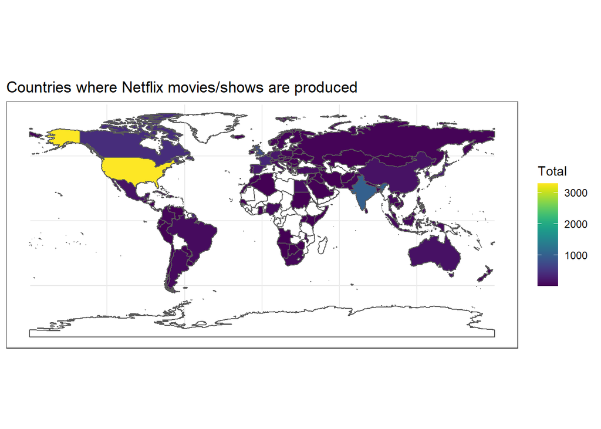

```r
full.list.map <- left_join(countries, nf.loc, by = c("admin" = "country"))
ggplot()+
  geom_sf(data = full.list.map, mapping = aes(fill = n))+
  scale_fill_viridis(na.value="white")+
  labs(title = "Countries where Netflix movies/shows are produced",
       fill = "Total")+
  theme_bw()
```

# scale it to population

Well, that is ok, but are we seeing a pattern where the larger population countries are producing higher numbers? Often, it is better to scale these measures to the total population. Here, I do it to number of entries per 100,000 people

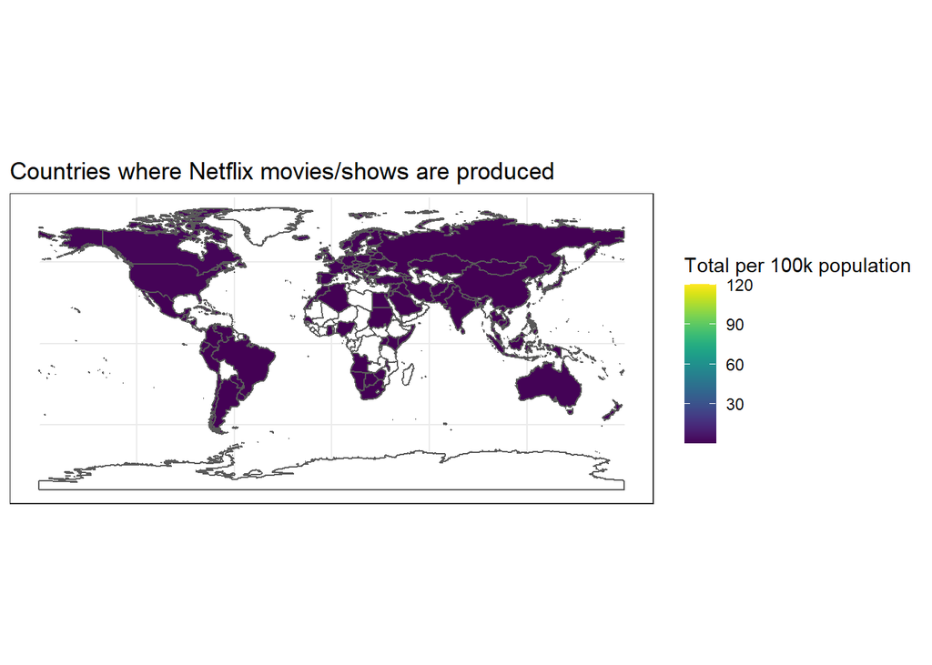

```r
full.list.map <- left_join(countries, nf.loc, by = c("admin" = "country"))
full.list.map <- full.list.map %>% mutate(titles.per100k = 100000 * n/pop_est)
ggplot()+
  geom_sf(data = full.list.map, mapping = aes(fill = titles.per100k))+
  scale_fill_viridis(na.value="white")+
  labs(title = "Countries where Netflix movies/shows are produced",
       fill = "Total per 100k population") +
  theme_bw()
```

What is going on here? Why is everything the same color? Where is something with 120 shows per 100,000 residents?

```r
full.list.map %>%
  st_set_geometry(NULL) %>%
  slice(which.max(titles.per100k))
```

```
##     admin continent pop_est gdp_md_est                    economy
## 1 Vatican    Europe     832        355 2. Developed region: nonG7
##                income_grp n titles.per100k
## 1 2. High income: nonOECD 1       120.1923
```

There is a movie in the Vatican, which only has 832 people, so it is skewed (and too small to see on the map). Let’s redo without that entry

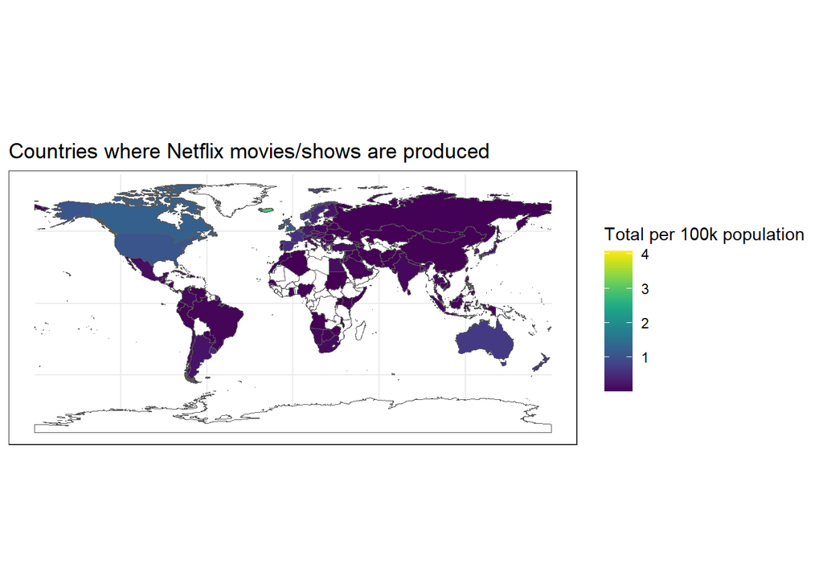

```r
ggplot()+
  geom_sf(data = full.list.map %>% filter(admin != "Vatican"), mapping = aes(fill = titles.per100k), size = .1)+
  scale_fill_viridis(na.value="white")+
  labs(title = "Countries where Netflix movies/shows are produced",
       fill = "Total per 100k population") +
  theme_bw()
```

# What about the counties economy?

Here is a quick table showing the different economic categories from the Natural Earth dataset

```r
full.list.map%>%
  st_set_geometry(NULL)%>%
  group_by(economy)%>%
  summarise(tot = sum(n, na.rm = T))
```

```
## # A tibble: 7 x 2
##   economy                      tot
##   <chr>                      <int>
## 1 1. Developed region: G7     5363
## 2 2. Developed region: nonG7   965
## 3 3. Emerging region: BRIC    1255
## 4 4. Emerging region: MIKT     554
## 5 5. Emerging region: G20      563
## 6 6. Developing region         344
## 7 7. Least developed region     19
```

And the income groups

```r
full.list.map%>%
  st_set_geometry(NULL)%>%
  group_by(income_grp)%>%
  summarise(tot = sum(n, na.rm = T))
```

```
## # A tibble: 5 x 2
##   income_grp                tot
##   <chr>                   <int>
## 1 1. High income: OECD     6412
## 2 2. High income: nonOECD   299
## 3 3. Upper middle income    936
## 4 4. Lower middle income   1394
## 5 5. Low income              22
```

And the same thing by continent

```r
full.list.map%>%
  st_set_geometry(NULL)%>%
  group_by(continent)%>%
  summarise(tot = sum(n, na.rm = T))
```

```
## # A tibble: 8 x 2
##   continent                 tot
##   <chr>                   <int>
## 1 Africa                    271
## 2 Antarctica                  0
## 3 Asia                     2392
## 4 Europe                   2081
## 5 North America            3875
## 6 Oceania                   173
## 7 Seven seas (open ocean)     1
## 8 South America             270
```

Very few Netflix movies are from Africa or South America!

# Over time

OK, lets get super fancy and run that first map over time.

```r
nf.loc.time <- netflix %>%
  separate_rows(country, sep = ", ")%>%
  mutate(country = recode(country,
                             "Bahamas" = "The Bahamas",
                             "Cambodia," = "Cambodia" ,
                             "East Germany" = "Germany" ,
                             "Hong Kong" = "Hong Kong S.A.R.",
                             "Poland," = "Poland",
                             "Serbia" = "Republic of Serbia",
                             "Soviet Union" = "Russia",
                             "United Kingdom," = "United Kingdom",
                          "United States" = "United States of America",
                          "United States," = "United States of America",
                          "Vatican City" = "Vatican"  ,
                          "West Germany" = "Germany"  ))%>%
  filter(!is.na(country))%>%
  group_by(country, release_year)%>%
  summarise(n = n())
```

```
## nframes and fps adjusted to match transition
```

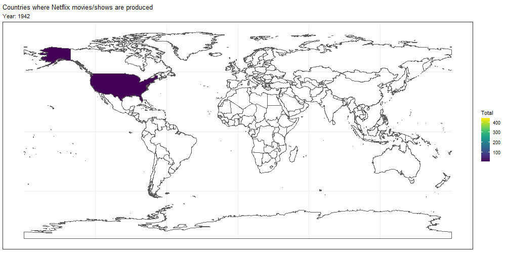

```r
full.list.map.time <- left_join(countries, nf.loc.time, by = c("admin" = "country"))

p.tot  <- ggplot()+
  geom_sf(data = countries, fill = NA)+
  geom_sf(data = full.list.map.time %>% filter(!is.na(release_year)), mapping = aes(fill = n))+
  scale_fill_viridis(na.value="white")+
  labs(title = "Countries where Netflix movies/shows are produced",
       subtitle = "Year: {current_frame}",
       fill = "Total")+
  theme_bw()+
  transition_manual(release_year)


animate(p.tot, duration = 15, fps = 20, width = 1000, height = 500, renderer = gifski_renderer())
```

```r
anim_save(filename = "netflix_movies.gif")
```